# Linear Regression Exercises

JG

9/1/22

# The R package “faraway” has the dataset “pima”. Install and load the R package “faraway”. Extract pima data with “data(pima)” command.

Variables are:

pregnant (# of times) glucose (2 hours post tolerance test) age (years) diastolic (blood pressure) tricepts (skin fold thickness) insulin (2-hour insulin) bmi diabetes (pedigree-a number related to family history) test (diabetes signs +/-)

```r
data("pima")

#Replace missing value of tricepts with mean
#

pima$triceps[0==pima$triceps] <- mean(pima$triceps[!0==pima$triceps],na.rm=TRUE)
pima$diastolic[0==pima$diastolic] <- mean(pima$diastolic[!0==pima$diastolic],na.rm=TRUE)
pima$bmi[0==pima$bmi] <- mean(pima$bmi[!0==pima$bmi],na.rm=TRUE)
```

1. Calculate summary of variables by “test” Perform Chi-squared test.
2. How many total subjects are there?
3. How many subjects have diabetes?
4. Which variables are NOT associated with diabetes test?

```r
tbl_summary(pima,by=test) %>% add_p(all_categorical() ~ "chisq.test")
```

| **Characteristic** | **0**, N = 500<sup>1</sup> | **1**, N = 268<sup>1</sup> | **p-value**<sup>2</sup> |
| --- | --- | --- | --- |
| pregnant | 2 (1, 5) | 4 (2, 8) | <0.001 |
| glucose | 107 (93, 125) | 140 (119, 167) | <0.001 |
| diastolic | 72 (64, 78) | 74 (68, 82) | <0.001 |
| triceps | 29 (22, 31) | 29 (29, 36) | <0.001 |
| insulin | 39 (0, 105) | 0 (0, 167) | 0.066 |
| bmi | 30 (26, 35) | 34 (31, 39) | <0.001 |
| diabetes | 0.34 (0.23, 0.56) | 0.45 (0.26, 0.73) | <0.001 |
| age | 27 (23, 37) | 36 (28, 44) | <0.001 |

<sup>1</sup> Median (IQR)  
<sup>2</sup> Wilcoxon rank sum test

5. Plot the distribution of diastolic. Describe distribution.

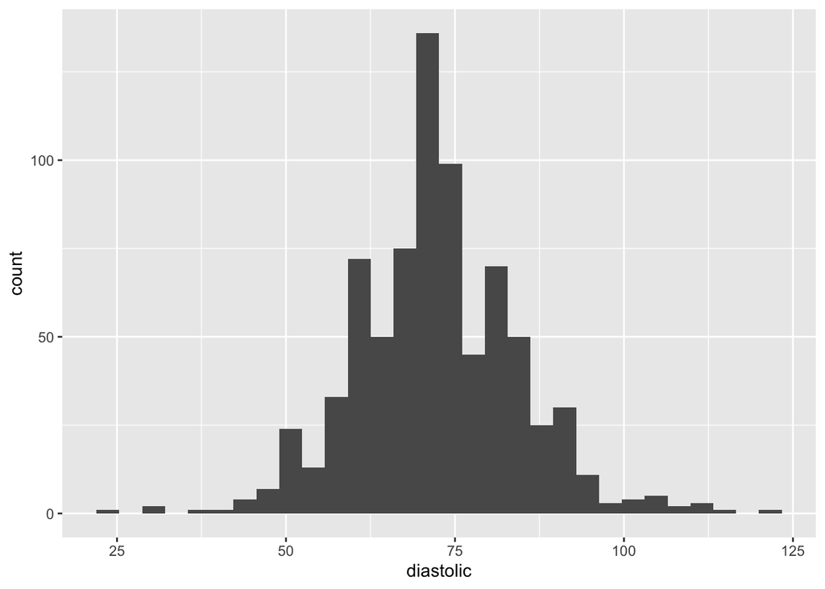

```r
ggplot(pima,aes(x=diastolic))+geom_histogram()
```

6. Which variables are correlated with diastolic blood pressure?

```r
with(pima,cor.test(diastolic,age))
```

```
##
##  Pearson's product-moment correlation
##
## data:  diastolic and age
## t = 9.498, df = 766, p-value < 2.2e-16
## alternative hypothesis: true correlation is not equal to 0
## 95 percent confidence interval:
##  0.2598169 0.3864647
## sample estimates:
##       cor
## 0.3245949
```

# Here is an example stepwise variable selection with AIC criterion.

7. Perform stepwise selection using the stepAIC function in the MASS R package. Use all variables as predictors!
8. Which model was selected as the best fit?

```r
lmout <- lm(diastolic~age+diabetes+triceps+bmi,data=pima)
stepAIC(lmout,direction="both")
```

```
## Start:  AIC=3682.78
## diastolic ~ age + diabetes + triceps + bmi
##
##            Df Sum of Sq    RSS    AIC
## - triceps   1       3.8  91683 3680.8
## <none>                   91679 3682.8
## - diabetes  1     353.3  92033 3683.7
## - bmi       1    6020.3  97700 3729.6
## - age       1   11159.9 102839 3769.0
##
## Step:  AIC=3680.81
## diastolic ~ age + diabetes + bmi
##
##            Df Sum of Sq    RSS    AIC
## <none>                   91683 3680.8
## - diabetes  1     352.1  92035 3681.8
## + triceps   1       3.8  91679 3682.8
## - bmi       1    8699.9 100383 3748.4
## - age       1   11424.7 103108 3769.0
```

```
##
## Call:
## lm(formula = diastolic ~ age + diabetes + bmi, data = pima)
##
## Coefficients:
## (Intercept)          age     diabetes          bmi
##     46.3711       0.3284      -2.0704       0.4958
```

9. Perform all possible regressions using regsubsets function in the leaps R package. Use all variables as predictors!
10. What model has the best BIC (Bayesian Information Criterion)?

```r
leaps<-regsubsets(diastolic~age+diabetes+triceps+bmi,data=pima,nbest=10)
# view results
summary(leaps)
```

```
## Subset selection object
## Call: regsubsets.formula(diastolic ~ age + diabetes + triceps + bmi,
##     data = pima, nbest = 10)
## 4 Variables  (and intercept)
##          Forced in Forced out
## age          FALSE      FALSE
## diabetes     FALSE      FALSE
## triceps      FALSE      FALSE
## bmi          FALSE      FALSE
## 10 subsets of each size up to 4
## Selection Algorithm: exhaustive
##          age diabetes triceps bmi
## 1  ( 1 ) "*" " "      " "     " "
## 1  ( 2 ) " " " "      " "     "*"
## 1  ( 3 ) " " " "      "*"     " "
## 1  ( 4 ) " " "*"      " "     " "
## 2  ( 1 ) "*" " "      " "     "*"
## 2  ( 2 ) "*" " "      "*"     " "
## 2  ( 3 ) "*" "*"      " "     " "
## 2  ( 4 ) " " " "      "*"     "*"
## 2  ( 5 ) " " "*"      " "     "*"
## 2  ( 6 ) " " "*"      "*"     " "
## 3  ( 1 ) "*" "*"      " "     "*"
## 3  ( 2 ) "*" " "      "*"     "*"
## 3  ( 3 ) "*" "*"      "*"     " "
## 3  ( 4 ) " " "*"      "*"     "*"
## 4  ( 1 ) "*" "*"      "*"     "*"
```

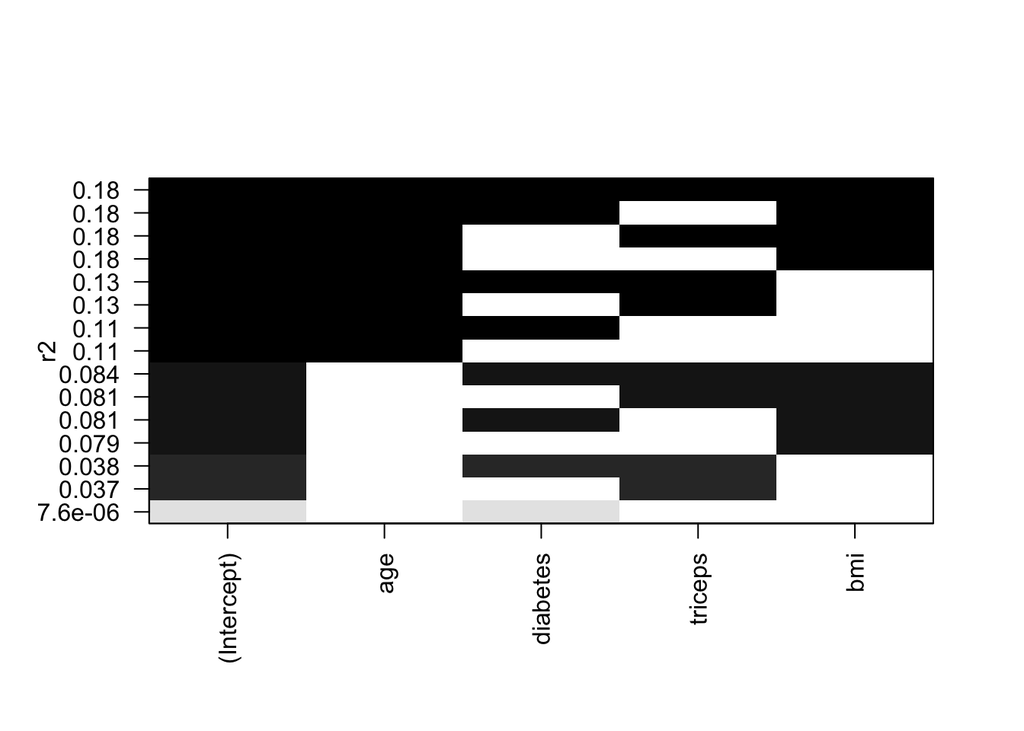

```r
# plot a table of models showing variables in each model.
# models are ordered by the selection statistic.
plot(leaps,scale="r2")
```

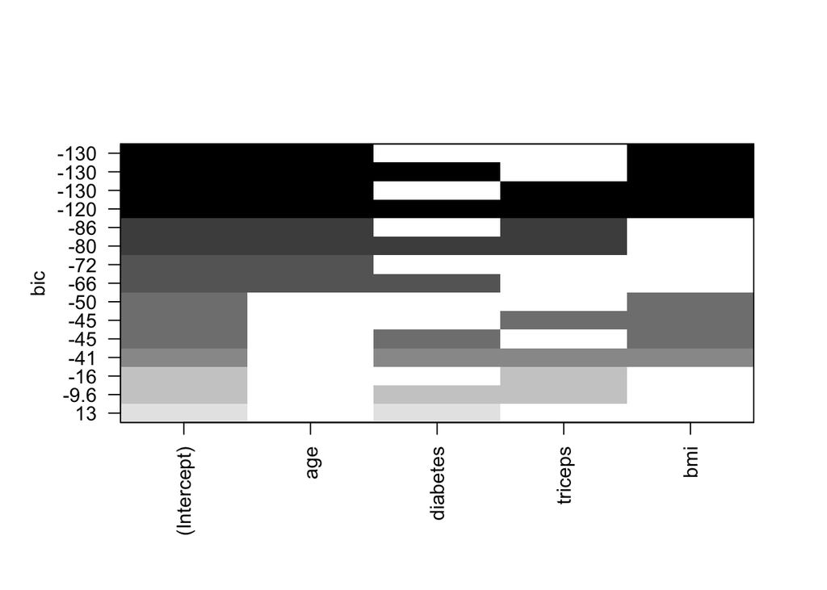

```r
plot(leaps,scale="bic")
```

11. Fit the model selected by BIC. What are the significant predictors?

```r
fitBIC <- lm(formula = diastolic ~ age + bmi, data = pima)

fitBIC %>% gtsummary::tbl_regression()
```

| **Characteristic** | **Beta** | **95% CI**<sup>1</sup> | **p-value** |
| --- | --- | --- | --- |
| age | 0.33 | 0.26, 0.39 | <0.001 |
| bmi | 0.48 | 0.37, 0.59 | <0.001 |

<sup>1</sup> CI = Confidence Interval

12. Look for “influential” observations whose removal effects the fit. We can compute the Cook’s distance using the following commands.
13. How is this an extreme observation?

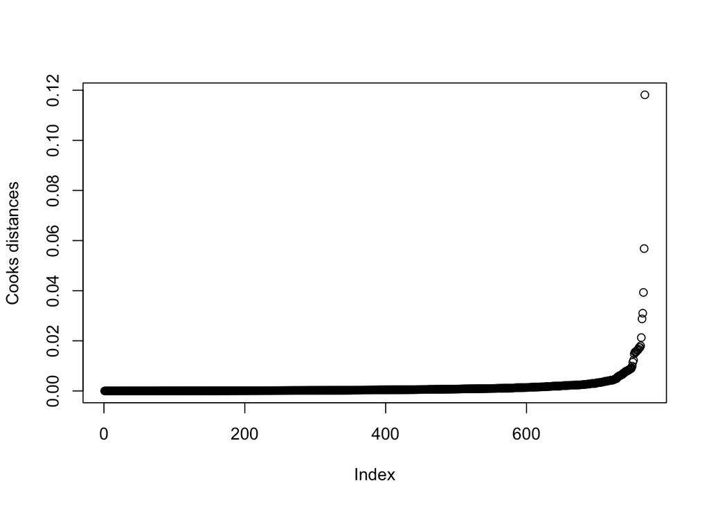

```r
cook <- cooks.distance(fitBIC)
plot(sort(cook), ylab="Cooks distances")
```

```r
print(pima[cook==max(cook),],)
```

```
##     pregnant glucose diastolic triceps insulin bmi diabetes age test
## 126        1      88        30      42      99  55    0.496  26    1
```

14. What does the plot below imply about diabetes risk and bmi?

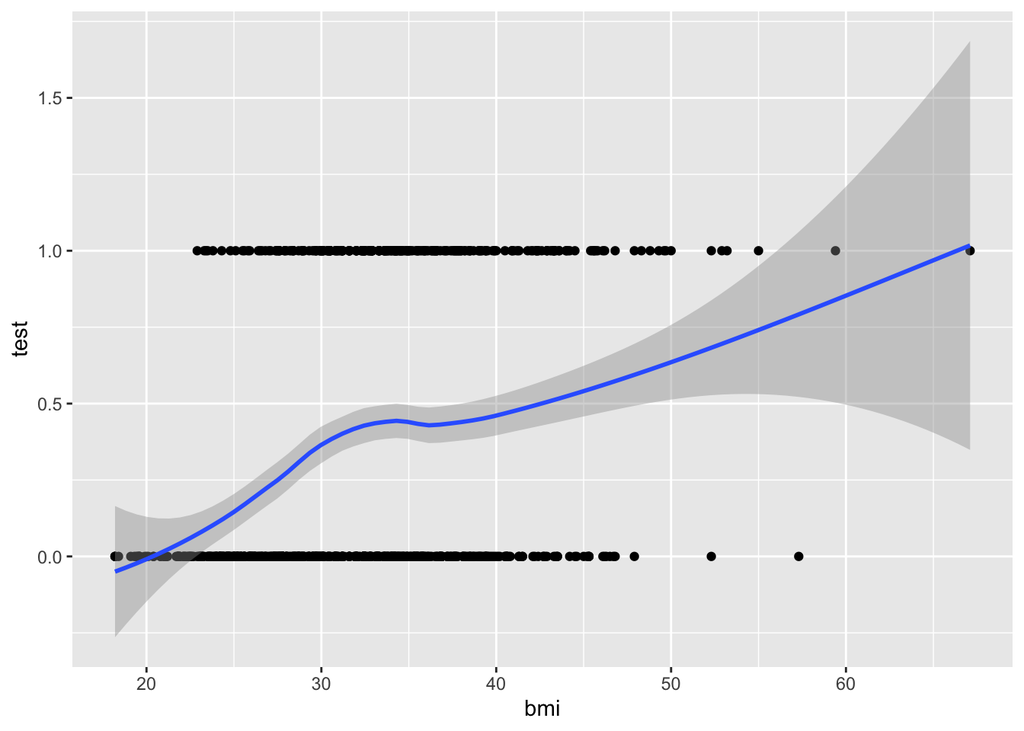

```r
ggplot(pima,aes(bmi,test))+geom_point()+geom_smooth()
```

15. According the the stepwise AIC model below, which variables best predict diabetes? Note, this is logistic regression.

```r
lmout <- glm(test~age+diastolic+pregnant+triceps+bmi,data=pima,family=binomial)
stepAIC(lmout,direction="both")
```

```
## Start:  AIC=871.86
## test ~ age + diastolic + pregnant + triceps + bmi
##
##             Df Deviance    AIC
## - diastolic  1   859.87 869.87
## - triceps    1   860.55 870.55
## <none>           859.86 871.86
## - pregnant   1   870.23 880.23
## - age        1   874.48 884.48
## - bmi        1   907.86 917.86
##
## Step:  AIC=869.87
## test ~ age + pregnant + triceps + bmi
##
##             Df Deviance    AIC
## - triceps    1   860.56 868.56
## <none>           859.87 869.87
## + diastolic  1   859.86 871.86
## - pregnant   1   870.23 878.23
## - age        1   875.53 883.53
## - bmi        1   910.92 918.92
##
## Step:  AIC=868.56
## test ~ age + pregnant + bmi
##
##             Df Deviance    AIC
## <none>           860.56 868.56
## + triceps    1   859.87 869.87
## + diastolic  1   860.55 870.55
## - pregnant   1   870.93 876.93
## - age        1   876.88 882.88
## - bmi        1   941.10 947.10
```

```
##
## Call:  glm(formula = test ~ age + pregnant + bmi, family = binomial,
##     data = pima)
##
## Coefficients:
## (Intercept)          age     pregnant          bmi
##    -5.74106      0.03271      0.08998      0.10989
##
## Degrees of Freedom: 767 Total (i.e. Null);  764 Residual
## Null Deviance:       993.5
## Residual Deviance: 860.6     AIC: 868.6
```